# Checkerboard - regression

Diana Proctor

2025-07-30

last updated: August 01 2025

chatGPT was used to help code this up

note: this is to analyze end-point data, not a time course!!!! here, we look at the 24h readings

```r
library(knitr)
opts_chunk$set(fig.width=12, fig.height=8,
               echo=TRUE, warning=FALSE, message=FALSE, error = FALSE)
```

Load R packages

```r
# Set seed
set.seed(78979)

# Define required packages
packages <- c(
  # Core tidyverse packages
  "tidyverse",

  # Phylogenetics and microbiome analysis
  "phyloseq",
  "microbiome",
  "phangorn",
  "msa",

  # Statistical modeling and analysis
  "lmerTest",
  "rstatix",
  "broom",
  "mediation",
  "effects",
  "broom.mixed",
  "genefilter",
  "vegan",
  "ALDEx2",

  # Visualization enhancements
  "ggpubr",
  "ggprism",
  "gridExtra",
  "ggbeeswarm",
  "ggrepel",
  "cowplot",
  "ggtext",
  "reshape2",
  "pheatmap",
  "ggfortify",

  # Data import
  "readxl"
)

# Install missing CRAN packages
cran_packages <- setdiff(packages, rownames(installed.packages()))
cran_packages <- cran_packages[!cran_packages %in% c("phyloseq", "microbiome", "phangorn", "msa", "genefilter", "vegan", "ALDEx2")]
if(length(cran_packages) > 0) install.packages(cran_packages)

# Install missing Bioconductor packages
bioc_packages <- c("phyloseq", "microbiome", "phangorn", "msa", "genefilter", "vegan", "ALDEx2")
bioc_to_install <- setdiff(bioc_packages, rownames(installed.packages()))
if(length(bioc_to_install) > 0) BiocManager::install(bioc_to_install, update = FALSE)

# Load packages
n <- length(packages) - sum(sapply(packages, require, character.only = TRUE))

# Print loading status
if (n == 0) {
  print("All necessary R packages loaded properly")
} else {
  print(paste0(n, " R packages did not load properly"))
}
```

```
## [1] "All necessary R packages loaded properly"
```

```r
#set graphs to the graphpad prism theme
theme_set(theme_bw())
```

read in the data and merge it together

specifically, we read in the replicates

```r
process_checkerboard_data <- function(file_path, sheet = 1) {
  # Read the Excel sheet
  raw_data <- read_excel(file_path, sheet = sheet)

  # Subset the data from row 26 onward
  data_subset <- as.data.frame(raw_data[26:nrow(raw_data), ])

  # Remove the first column
  data_subset <- data_subset[, -1]

  # Remove the first row
  cleaned_data <- data_subset[-1, ]
  cleaned_data$file = file_path
  return(cleaned_data)
}

file1 <- "~/Desktop/Staff/Sanduni/Checkerboard assays_Van_Flu_old RPMI/Vanco_Fluco_Pilot Experiment_19_05_2024.xlsx"
rep1 <- process_checkerboard_data(file1)


file2 <- "~/Desktop/Staff/Sanduni/Checkerboard assays_Van_Flu_old RPMI/Vanco_Fluco_Replicate 1_24_05_2024.xlsx"
rep2 <- process_checkerboard_data(file2)


file3 <- "~/Desktop/Staff/Sanduni/Checkerboard assays_Van_Flu_old RPMI/Vanco_Fluco_Replicate 2_ Reading 1_24_05_2025.xlsx"
rep3 <- process_checkerboard_data(file3)

file4 <- "~/Desktop/Staff/Sanduni/Checkerboard assays_Van_Flu_old RPMI/Vanco_Fluco_Replicate2 _Reading 2_24_05_2025.xlsx"
rep4 <- process_checkerboard_data(file4)

#make a dataset of all the data
od_df = data.frame(rbind(rep2, rep3, rep4)) #need to add rep1

#melt the data
colnames(od_df) = c("Row", 1:12, "wv", "file")
# Pivot longer
od_long <- od_df %>%
  pivot_longer(
    cols = `1`:`12`,         # melt columns 1 to 12
    names_to = "Col",     # new column with the original column names
    values_to = "OD"         # new column with OD values
  )
```

read in the metadata

```r
# Load metadata
file="~/Desktop/Staff/Sanduni/Checkerboard assays_Van_Flu_old RPMI/Checkerboard_Van_Flu_23_06_25 @24hr.xlsx"
meta_df <- read_excel(file, sheet =2)

# Rename row identifiers
colnames(meta_df)[1] <- "Row"
```

merge the data and clean it up

```r
meta_long <- meta_df %>%
  pivot_longer(-Row, names_to = "Col", values_to = "Condition")

# Combine OD + metadata
data <- left_join(od_long, meta_long, by = c("Row", "Col")) %>%
  filter(!is.na(OD), !grepl("EMPTY", OD, ignore.case = TRUE), !is.na(Condition)) %>%
  mutate(OD = as.numeric(OD))

# Extract Van and Flu concentrations
data2 <- data %>%
  mutate(
    FluRaw = str_extract(Condition, "Flu\\s*[0-9.]+"),
    FluConc = as.numeric(str_extract(FluRaw, "[0-9.]+")),
    VanRaw = str_extract(Condition, "Van\\s*[0-9.]+"),
    VanConc = as.numeric(str_extract(VanRaw, "[0-9.]+"))
  )
```

merge OD with pH data

```r
#read in the pH data
phdata = read_excel("~/Desktop/ABX_Project/pH and Matrices.xlsx")
phdata_long <- phdata %>%
  dplyr::rename(Van = `Van/Flu`) %>%
  pivot_longer(
    cols = -Van,
    names_to = "Flu",
    values_to = "pH"
  ) %>%
  mutate(Flu = as.numeric(Flu))

#merge pH data with the OD data
mydata = merge(phdata_long, data2  )
#View(mydata)


mydata = subset(mydata, Condition !="EMPTY")
#look at predictors
table(mydata$pH) #pH varies between 5 and 6; it's a qualitative assessment not numeric
```

```
##
##     5   5.5     6
##  1449  1449 10143
```

```r
#how correlated are they?
cor(mydata$Van, as.numeric(as.character(mydata$pH))) #very
```

```
## [1] -0.9717678
```

let’s look at the data

```r
p = ggplot(mydata, aes(sqrt(pH), sqrt(Van))) + geom_point()
p= ggplot(mydata, aes(as.factor(Van), OD)) + geom_boxplot() + facet_wrap(~Flu)
p= ggplot(mydata, aes(as.factor(pH), OD)) + geom_boxplot() + facet_wrap(~Flu)
```

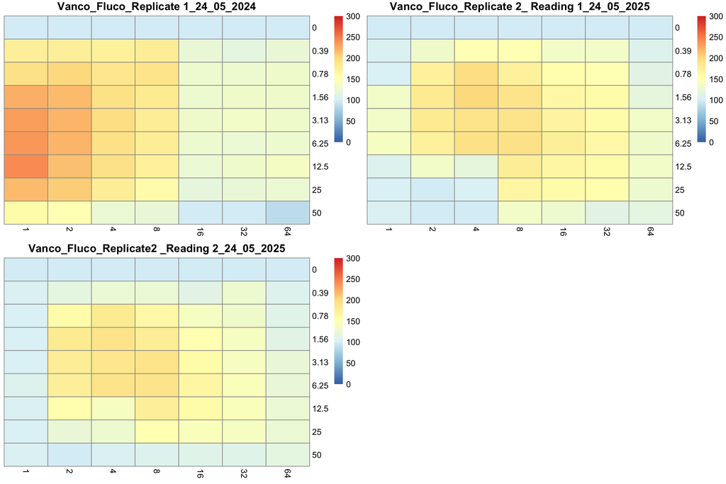

```r
# Get control OD values per file and FluConc
control_vals <- data2 %>%
  filter(
    str_detect(Condition, regex("Control", ignore_case = TRUE)) &
    str_detect(Condition, regex("Van 0", ignore_case = TRUE))
  ) %>%
  group_by(file, FluConc) %>%
  summarise(Control_OD = mean(OD, na.rm = TRUE), .groups = "drop")

#Join back to full dataset
data3 <- left_join(data2, control_vals, by = c("file", "FluConc")) %>%
  mutate(GrowthPercent = (OD / Control_OD) * 100)

# create heatmap matrix per file (list of matrices)
heatmap_list <- data3 %>%
  group_by(file, VanConc, FluConc) %>%
  summarise(Growth = mean(GrowthPercent, na.rm = TRUE), .groups = "drop") %>%
  filter(!is.na(FluConc), FluConc != 0) %>%   # remove NA and zero fluconazole columns
  group_split(file) %>%
  setNames(unique(data3$file)) %>%
  lapply(function(df) {
    # Pivot so rows = VanConc, columns = FluConc, values = Growth
    mat_data <- df %>%
      pivot_wider(names_from = FluConc, values_from = Growth) %>%
      arrange(VanConc)         # sort rows by VanConc ascending

    # Remove rows with NA VanConc (if any)
    mat_data <- mat_data %>% filter(!is.na(VanConc))

    # Remove columns that are all NA (sometimes happens if a FluConc had no data)
    na_cols <- sapply(mat_data, function(col) all(is.na(col)))
    mat_data <- mat_data[, !na_cols]

    # Extract matrix without the VanConc column
    mat <- as.matrix(mat_data[, !(names(mat_data) %in% c("VanConc", "file"))])


    # Ensure matrix is numeric (important for plotting)
    mode(mat) <- "numeric"

    # Assign VanConc values as row names
    rownames(mat) <- as.character(mat_data$VanConc)

    return(mat)
  })

########plot the heatmaps for each file
color_breaks <- seq(0, 300, length.out = 100)  # fixed color scale from 0 to 300

heatmap_plots <- list()

for (file_name in names(heatmap_list)) {
  file_base <- tools::file_path_sans_ext(basename(file_name))

  heatmap_obj <- pheatmap(
    heatmap_list[[file_name]],
    cluster_rows = FALSE,
    cluster_cols = FALSE,
    main = file_base,
    silent = TRUE,
    breaks = color_breaks
  )

  heatmap_plots[[file_base]] <- heatmap_obj[[4]]
}
combined_plot <- cowplot::plot_grid(plotlist = heatmap_plots, ncol = 2)  # or adjust ncol
combined_plot
```

let’s get the average of the three replicates

```r
# Assuming heatmap_list contains matrices of identical dimensions

# Convert list to 3D array: [row, col, replicate]
heatmap_array <- simplify2array(heatmap_list)

# Compute mean across the third dimension (replicates)
average_matrix <- apply(heatmap_array, c(1, 2), mean, na.rm = TRUE)

# View or return the result
print(average_matrix)
```

```
##             1        2        4        8       16       32       64
## 0    100.0000 100.0000 100.0000 100.0000 100.0000 100.0000 100.0000
## 0.39 127.7550 140.7649 149.1604 150.6259 124.5344 126.9687 112.8571
## 0.78 132.3757 177.1715 187.3563 173.5688 141.6824 136.7340 119.4643
## 1.56 153.0738 192.8120 194.6781 183.1151 147.8273 144.3224 121.9643
## 3.13 156.7721 192.2051 190.8409 186.6380 153.2344 145.4457 129.7024
## 6.25 161.1545 188.1204 190.3735 186.6724 155.8974 144.3938 127.8571
## 12.5 150.9378 168.8759 150.4415 174.5851 149.5906 145.7692 133.0952
## 25   140.4343 143.1943 135.7651 158.7941 140.7108 139.1586 126.3095
## 50   122.9931 116.7508 110.9544 122.2423 112.9825 107.7721 107.2024
```